# Anomaly Detection

## Multivariate Normal Approximation

To begin our exploration of anomaly detection, we will look at the following dataset of credit application scoring: https://archive.ics.uci.edu/ml/datasets/Statlog+(German+Credit+Data). The file *german.data* contains the raw data and te file *german.doc* contains the field descriptions. The fields are qualitative and numerical fields such as *Status of existing checking account* (qualitative), *Credit history* (qualitative), *Credit amount requested* (numerical), and so on.

The final column of this dataset contains a manually label for creditworthiness, where *1* is *good*, and *2* is *bad*. In practice, we may or may not have access to handlabeled training data. Some potential ways to deal with it are:

1. manually label some training data yourselves (or crowdsource it through Mechanical Turk type services),
2. fully unsupervised approaches.

We will start off assuming we have some labeled samples.

### Exercise

Load in *german.data* and encode categorical variables with dummy variables. Pull out the last column as a separate variable. How many data points do we have? How many are credit-worthy (inliers)?

```r
raw_credit <- read.csv('german.data', header=FALSE, sep="")
encoded_credit.all <- model.matrix( ~ V1 + V2 + V3 + V4 + V6 + V7 + V8 + V9 + V10 + V11 + V12 + V13 + V14 + V15 + V16 + V17 + V18 + V19 + V20, raw_credit)[,-1]
y.all <- as.matrix(raw_credit[21])
```

### Exercise

Assuming we have labeled data, we only train our model on inliers and test on both inliers and outliers. So let us split out inliers ($y==1$) into an $75-25$ train-test split. All outliers will go into the test split.

```r
inlier_idx <- which(y.all==1)

# want 75% of the inlier set
smp_size <- floor(0.75 * length(inlier_idx))
# set the seed to make your partition reproductible
set.seed(123)
train_idx <- inlier_idx[ sample(seq_len(length(inlier_idx)), size = smp_size) ]

encoded_credit.train <- encoded_credit.all[train_idx, ]
encoded_credit.test <- encoded_credit.all[-train_idx, ]

y.train <- y.all[train_idx]
y.test <- y.all[-train_idx]
```

### Exercise

Let’s try the Gaussian density approximation method. Use the methods *colMeans*, and *cov* to fit the distribution to the training data. Then visualize the distance distribution (using the *mahalanobis* function) with a histogram. Based on this alone, what distance value might you use as a threshold?

*Note*: You would normally want a train-test-dev split, or cross-validation here so that you can pick the threshold optimally. We are being lazy for the purposes of instruction.

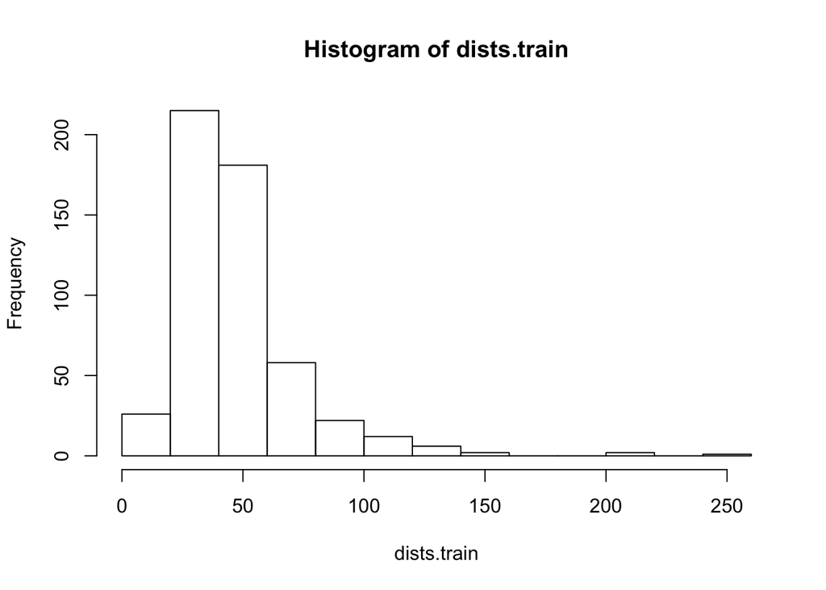

```r
mvn.mean <- colMeans(encoded_credit.train)
mvn.cov <- cov(encoded_credit.train)
dists.train <- mahalanobis(encoded_credit.train, mvn.mean, mvn.cov)
hist(dists.train)
```

### Exercise

##### Calculate distances for the test set, plot another distance of histograms. Do you notice anything different as compared to the previous histogram? Why (or why not) is that occuring?

##### Plot the ROC curve (using *plot.roc* from the *pROC* package), and calculate the area under the ROC curve (using *auc* from the *pROC* package).

##### What point of the ROC curve would you use to pick the threshold? What are all the considerations that go into making this decision?

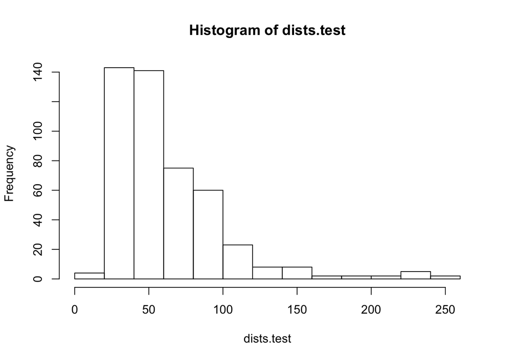

```r
# compute and plot the distance histogram
dists.test <- mahalanobis(encoded_credit.test, mvn.mean, mvn.cov)
hist(dists.test)
```

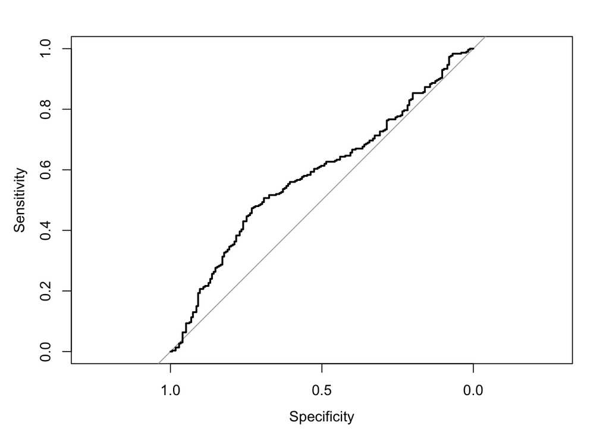

```r
# plot ROC curve
plot.roc(y.test, dists.test)
```

```r
# compute the AUC
auc(y.test, dists.test)
```

```
## Area under the curve: 0.5834
```

We note that the tail of the distribution (values past $~ 150$) is heavier. This is expected because our test set contains the anomalies we are trying to detect, so we would hope they are further away.

We cannot just say we would pick the *knee point* - we have to ask is it better to make one type of error versus another? i.e. is it better to deny credit to good candidates versus giving credit to bad ones? Typically for credit, the answer is no, but you will need to quantify the cost of these error rates (and it can be hard to do) and decide what the optimal trade-off is. This is a business decision, not just a machine learning one.

## PCA reconstruction method.

### Exercise:

Compute the centered and scaled PCA (using *prcomp*) for the training set. And visualize the plot of variance explained as a function of number of components. Pick the appropriate number of components.

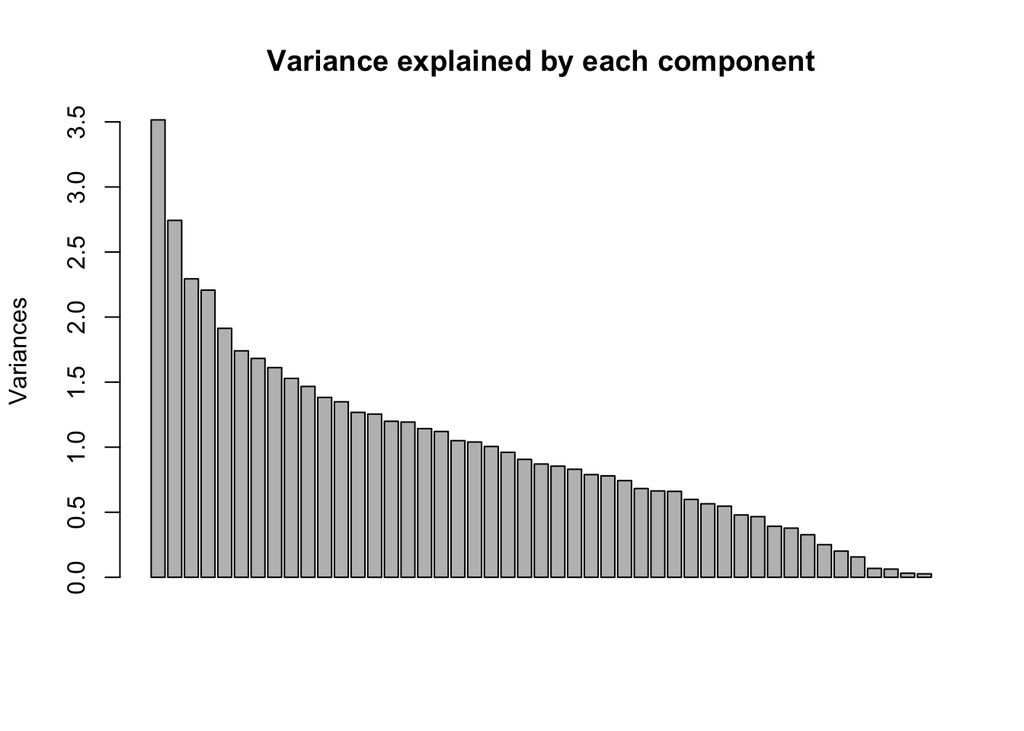

```r
# compute PCA
pca.train <- prcomp(encoded_credit.train, center = TRUE, scale. = TRUE)

# plot of variance explained by each component
plot(pca.train, npcs=47, main="Variance explained by each component")
```

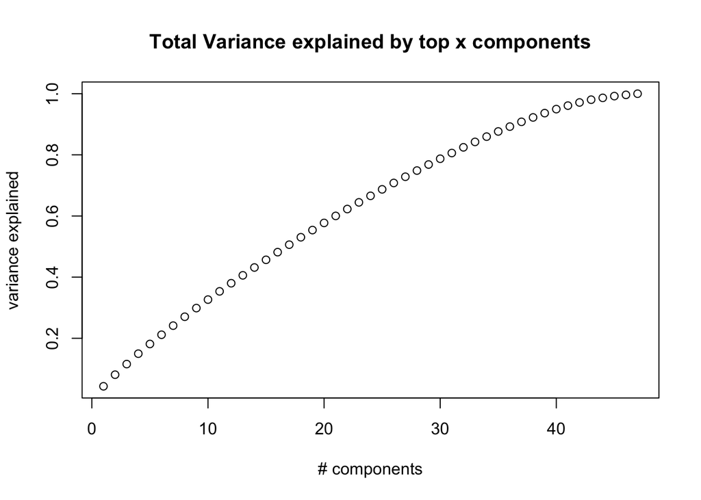

```r
# make the cumulative plot
plot(cumsum(pca.train$sdev)/sum(pca.train$sdev), xlab="# components",
     ylab="variance explained", main="Total Variance explained by top x components")
```

### Exercise

##### Pick a number of components you want to use. It is not straightforward in this case - you would definitely want to use a validation set here when doing it in practice.

##### Compute reconstruction error for the training set, look at histograms of distances. Be careful about dealing with scaling and cetering your PCA reconstruction (I used the *scale* function).

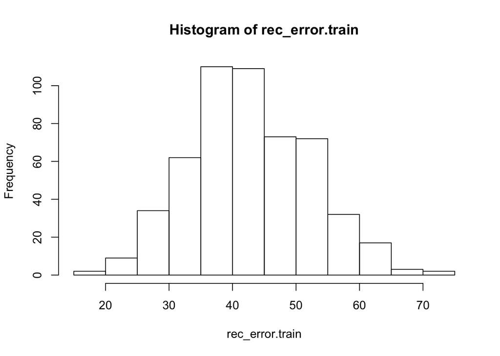

```r
pc.use <- 30 # explains ~80% of variance

project_pca <- getS3method("predict", "prcomp")

reconstructed_credit.train <- project_pca(pca.train, encoded_credit.train)[,1:pc.use] %*% t(pca.train$rotation[,1:pc.use])

# and add the center (and re-scale) back to data
reconstructed_credit.train <- scale(reconstructed_credit.train, center = FALSE , scale=1/pca.train$scale)
reconstructed_credit.train <- scale(reconstructed_credit.train, center = -1 * pca.train$center, scale=FALSE)

# define an l2 norm distance function
vecnorm <- function(x) { sqrt(sum(x^2)) }

rec_error.train <- apply(reconstructed_credit.train, 1, vecnorm)
hist(rec_error.train)
```

### Exercise

##### Compute reconstruction error for the test set, look at histograms of distances.

##### Plot the ROC curve and compute the AUC for the test set as in the previous approach.

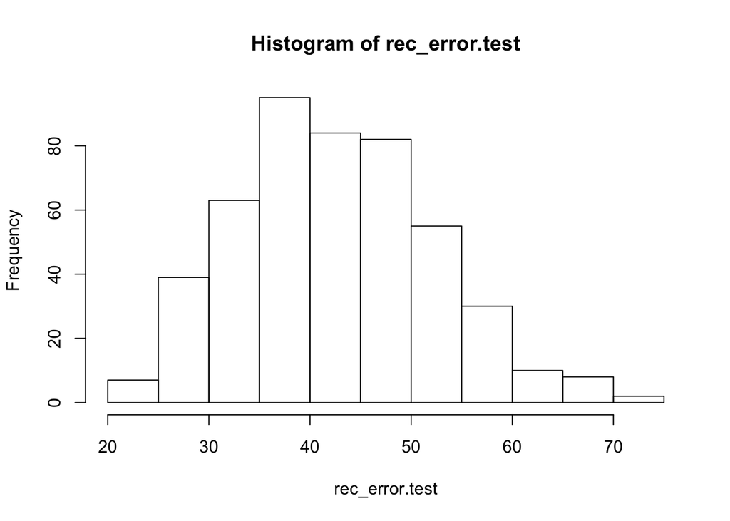

```r
# project the encoded data into the top principal components
reconstructed_credit.test <- project_pca(pca.train, encoded_credit.test)[,1:pc.use] %*% t(pca.train$rotation[,1:pc.use])

# and add the center (and re-scale) back to data
reconstructed_credit.test <- scale(reconstructed_credit.test, center = FALSE , scale=1/pca.train$scale)
reconstructed_credit.test <- scale(reconstructed_credit.test, center = -1 * pca.train$center, scale=FALSE)

# compute and plot the histogram
rec_error.test <- apply(reconstructed_credit.test, 1, vecnorm)
hist(rec_error.test)
```

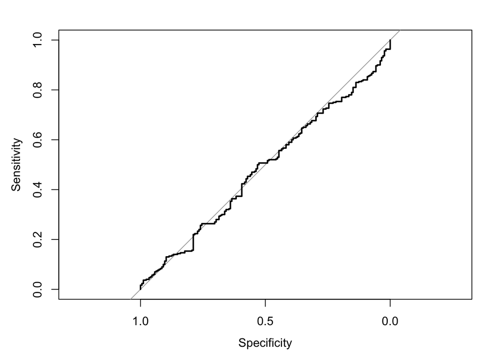

```r
# plot ROC curve
plot.roc(y.test, rec_error.test)
```

```r
# compute the AUC
auc(y.test, rec_error.test)
```

```
## Area under the curve: 0.4845
```

## Multivariate Covariance Determinant

Consider the scenario where we had some labeled examples of anomalies, but we cannot be sure that all examples of anomalies were labeled. For instance, we may have some examples of credit card fraud, but the remaining transactions may also contain frauduent transactions that we were not able to catch. This is the scenario where we would use multivariate covariance determination (MCD).

### Exercise

##### Find the MCD estimates of mean and covariance (use the *covMcd* function with an appropriate setting of *alpha*) on the train set.

##### You will run into a warning complaining that the covariance matrix is singular. What can you do about this?

##### Compute the Mahalanobis distances for the test set, plot the ROC curve and compute AUC.

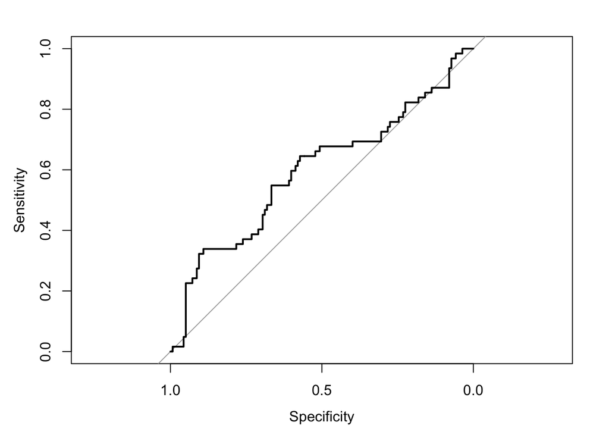

```r
## resample to create new train-test splits
smp_size <- floor(0.8 * nrow(encoded_credit.all))

## set the seed to make your partition reproductible
set.seed(123)
train_idx <- sample(seq_len(nrow(encoded_credit.all)), size = smp_size)

encoded_credit.train2 <- encoded_credit.all[train_idx, ]
encoded_credit.test2 <- encoded_credit.all[-train_idx, ]

# add a tiny bit of noise to deal with the problem of singular covariance matrix
encoded_credit.train2 <- encoded_credit.train2 + matrix(rnorm(length(encoded_credit.train2),0,0.00001), ncol=ncol(encoded_credit.train2))

y.train2 <- y.all[train_idx]
y.test2 <- y.all[-train_idx]

mcd <- covMcd(encoded_credit.train2)

mcd_dists.test <- mahalanobis(encoded_credit.test2, mcd$center, mcd$cov)

# plot ROC curve
plot.roc(y.test2, mcd_dists.test)
```

```r
# compute the AUC
auc(y.test2, mcd_dists.test)
```

```
## Area under the curve: 0.5956
```

## One Class SVM

Our dataset contains a lot of categorical variables, which become dummy variables with binomail coefficients. All the techniques we have used so far make assumptions of normality. We will try some non-parametric classification-based methods. We will use the train-test splits from the multivariate Guassian and PCA examples.

### Exercise

##### Using the original train-test split, train a one-class SVM model

##### Print the confusion matrix (SVMs do not produce continuous scores that we can use to compute an AUC).

```r
oneclass_svm.model <- svm(encoded_credit.train, y=NULL, type='one-classification', nu=0.10, scale=TRUE, kernel="radial")
```

```r
oneclass_svm.test <- predict(oneclass_svm.model, encoded_credit.test)
oneclass_svm.confusionMatrix <- table(Predicted=oneclass_svm.test,Reference=y.test)
table(Predicted=oneclass_svm.test,Reference=y.test)
```

```
##          Reference
## Predicted   1   2
##     FALSE  37  71
##     TRUE  138 229
```

Isolation Forests would be a good candidate to try on this as well. However, installing it on all platforms is not easy: https://github.com/Zelazny7/isofor . There is also a Python implementation in scikit-learn also, for people who want to try it.

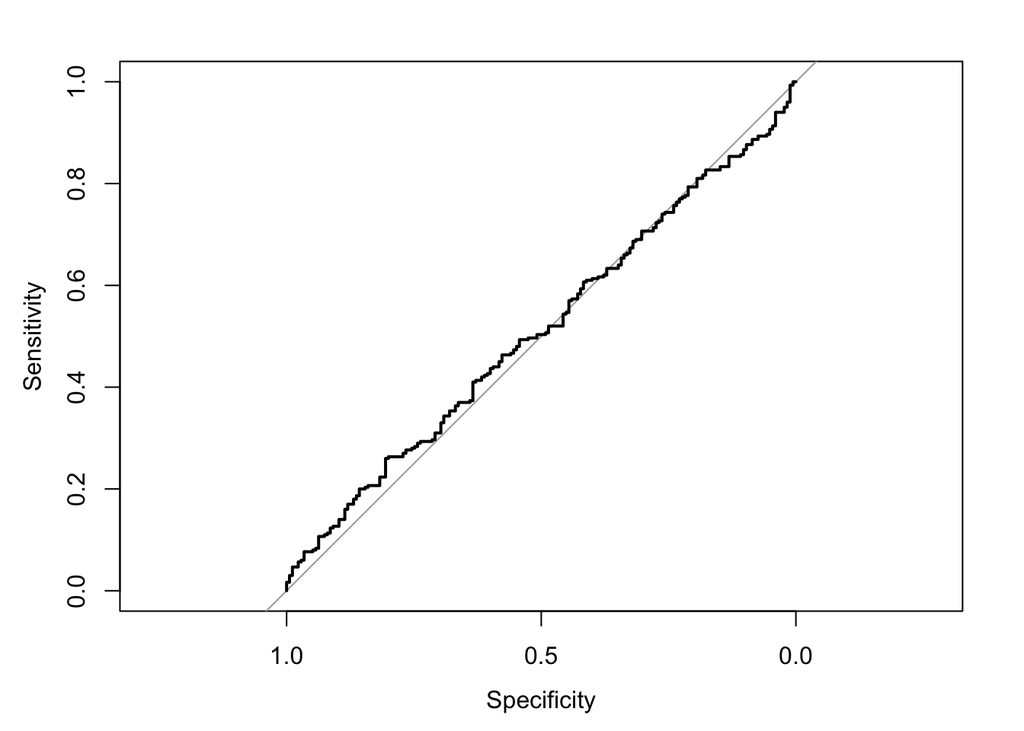

```r
library(isofor)

iforest.model <- iForest(X=encoded_credit.train, 100, 200)
iforest.test <- predict(iforest.model, encoded_credit.test)

# plot ROC curve
plot.roc(y.test, iforest.test)
```

```r
# compute the AUC
auc(y.test, iforest.test)
```

```
## Area under the curve: 0.51
```